# Risk Factor Analysis

## Outcome Variable

**Outcome Variable:** ever_co

## Predictor Variables

**Intervention Variable:** impsan

**Adjustment Set:**

- arm
- sex
- W_mage
- meducyrs
- feducyrs
- hhwealth_quart
- hfoodsec
- W_mhtcm
- W_mwtkg
- W_mbmi
- W_nrooms
- W_nchldlt5
- W_parity
- impfloor
- safeh20
- delta_W_mage
- delta_meducyrs
- delta_feducyrs
- delta_hhwealth_quart
- delta_hfoodsec
- delta_W_mhtcm
- delta_W_mwtkg
- delta_W_mbmi
- delta_W_nrooms
- delta_W_nchldlt5
- delta_W_parity
- delta_impfloor
- delta_safeh20

## Stratifying Variables

The analysis was stratified on these variable(s):

- agecat
- studyid
- country

## Data Summary

| agecat | studyid | country | impsan | ever_co | n_cell | n |
| --- | --- | --- | --- | --- | --- | --- |
| 0-24 months | ki0047075b-MAL-ED | BANGLADESH | 1 | 0 | 171 | 242 |
| 0-24 months | ki0047075b-MAL-ED | BANGLADESH | 1 | 1 | 33 | 242 |
| 0-24 months | ki0047075b-MAL-ED | BANGLADESH | 0 | 0 | 32 | 242 |
| 0-24 months | ki0047075b-MAL-ED | BANGLADESH | 0 | 1 | 6 | 242 |
| 0-24 months | ki0047075b-MAL-ED | BRAZIL | 1 | 0 | 203 | 210 |
| 0-24 months | ki0047075b-MAL-ED | BRAZIL | 1 | 1 | 3 | 210 |
| 0-24 months | ki0047075b-MAL-ED | BRAZIL | 0 | 0 | 4 | 210 |
| 0-24 months | ki0047075b-MAL-ED | BRAZIL | 0 | 1 | 0 | 210 |
| 0-24 months | ki0047075b-MAL-ED | INDIA | 1 | 0 | 93 | 233 |
| 0-24 months | ki0047075b-MAL-ED | INDIA | 1 | 1 | 15 | 233 |
| 0-24 months | ki0047075b-MAL-ED | INDIA | 0 | 0 | 89 | 233 |
| 0-24 months | ki0047075b-MAL-ED | INDIA | 0 | 1 | 36 | 233 |
| 0-24 months | ki0047075b-MAL-ED | NEPAL | 1 | 0 | 213 | 236 |
| 0-24 months | ki0047075b-MAL-ED | NEPAL | 1 | 1 | 22 | 236 |
| 0-24 months | ki0047075b-MAL-ED | NEPAL | 0 | 0 | 1 | 236 |
| 0-24 months | ki0047075b-MAL-ED | NEPAL | 0 | 1 | 0 | 236 |
| 0-24 months | ki0047075b-MAL-ED | PERU | 1 | 0 | 60 | 263 |
| 0-24 months | ki0047075b-MAL-ED | PERU | 1 | 1 | 5 | 263 |
| 0-24 months | ki0047075b-MAL-ED | PERU | 0 | 0 | 192 | 263 |
| 0-24 months | ki0047075b-MAL-ED | PERU | 0 | 1 | 6 | 263 |
| 0-24 months | ki0047075b-MAL-ED | SOUTH AFRICA | 1 | 0 | 3 | 250 |
| 0-24 months | ki0047075b-MAL-ED | SOUTH AFRICA | 1 | 1 | 1 | 250 |
| 0-24 months | ki0047075b-MAL-ED | SOUTH AFRICA | 0 | 0 | 226 | 250 |
| 0-24 months | ki0047075b-MAL-ED | SOUTH AFRICA | 0 | 1 | 20 | 250 |
| 0-24 months | ki0047075b-MAL-ED | TANZANIA, UNITED REPUBLIC OF | 1 | 0 | 0 | 241 |
| 0-24 months | ki0047075b-MAL-ED | TANZANIA, UNITED REPUBLIC OF | 1 | 1 | 0 | 241 |
| 0-24 months | ki0047075b-MAL-ED | TANZANIA, UNITED REPUBLIC OF | 0 | 0 | 218 | 241 |
| 0-24 months | ki0047075b-MAL-ED | TANZANIA, UNITED REPUBLIC OF | 0 | 1 | 23 | 241 |
| 0-24 months | ki1017093-NIH-Birth | BANGLADESH | 1 | 0 | 196 | 624 |
| 0-24 months | ki1017093-NIH-Birth | BANGLADESH | 1 | 1 | 46 | 624 |

[output cut: 174 more lines]

The following strata were considered:

- agecat: 0-24 months, studyid: ki0047075b-MAL-ED, country: BANGLADESH
- agecat: 0-24 months, studyid: ki0047075b-MAL-ED, country: BRAZIL
- agecat: 0-24 months, studyid: ki0047075b-MAL-ED, country: INDIA
- agecat: 0-24 months, studyid: ki0047075b-MAL-ED, country: NEPAL
- agecat: 0-24 months, studyid: ki0047075b-MAL-ED, country: PERU
- agecat: 0-24 months, studyid: ki0047075b-MAL-ED, country: SOUTH AFRICA
- agecat: 0-24 months, studyid: ki0047075b-MAL-ED, country: TANZANIA, UNITED REPUBLIC OF
- agecat: 0-24 months, studyid: ki1017093-NIH-Birth, country: BANGLADESH
- agecat: 0-24 months, studyid: ki1017093b-PROVIDE, country: BANGLADESH
- agecat: 0-24 months, studyid: ki1017093c-NIH-Crypto, country: BANGLADESH
- agecat: 0-24 months, studyid: ki1114097-CONTENT, country: PERU
- agecat: 0-24 months, studyid: ki1135781-COHORTS, country: GUATEMALA
- agecat: 0-24 months, studyid: ki1135781-COHORTS, country: INDIA
- agecat: 0-24 months, studyid: ki1135781-COHORTS, country: PHILIPPINES
- agecat: 0-24 months, studyid: ki1148112-LCNI-5, country: MALAWI
- agecat: 0-24 months, studyid: kiGH5241-JiVitA-3, country: BANGLADESH
- agecat: 0-24 months, studyid: kiGH5241-JiVitA-4, country: BANGLADESH
- agecat: 0-6 months, studyid: ki0047075b-MAL-ED, country: BANGLADESH
- agecat: 0-6 months, studyid: ki0047075b-MAL-ED, country: BRAZIL
- agecat: 0-6 months, studyid: ki0047075b-MAL-ED, country: INDIA
- agecat: 0-6 months, studyid: ki0047075b-MAL-ED, country: NEPAL
- agecat: 0-6 months, studyid: ki0047075b-MAL-ED, country: PERU
- agecat: 0-6 months, studyid: ki0047075b-MAL-ED, country: SOUTH AFRICA
- agecat: 0-6 months, studyid: ki0047075b-MAL-ED, country: TANZANIA, UNITED REPUBLIC OF
- agecat: 0-6 months, studyid: ki1017093-NIH-Birth, country: BANGLADESH
- agecat: 0-6 months, studyid: ki1017093b-PROVIDE, country: BANGLADESH
- agecat: 0-6 months, studyid: ki1017093c-NIH-Crypto, country: BANGLADESH
- agecat: 0-6 months, studyid: ki1114097-CONTENT, country: PERU
- agecat: 0-6 months, studyid: ki1135781-COHORTS, country: GUATEMALA
- agecat: 0-6 months, studyid: ki1135781-COHORTS, country: INDIA
- agecat: 0-6 months, studyid: ki1135781-COHORTS, country: PHILIPPINES
- agecat: 0-6 months, studyid: ki1148112-LCNI-5, country: MALAWI
- agecat: 0-6 months, studyid: kiGH5241-JiVitA-3, country: BANGLADESH
- agecat: 0-6 months, studyid: kiGH5241-JiVitA-4, country: BANGLADESH
- agecat: 6-24 months, studyid: ki0047075b-MAL-ED, country: BANGLADESH
- agecat: 6-24 months, studyid: ki0047075b-MAL-ED, country: BRAZIL
- agecat: 6-24 months, studyid: ki0047075b-MAL-ED, country: INDIA
- agecat: 6-24 months, studyid: ki0047075b-MAL-ED, country: NEPAL
- agecat: 6-24 months, studyid: ki0047075b-MAL-ED, country: PERU
- agecat: 6-24 months, studyid: ki0047075b-MAL-ED, country: SOUTH AFRICA
- agecat: 6-24 months, studyid: ki0047075b-MAL-ED, country: TANZANIA, UNITED REPUBLIC OF
- agecat: 6-24 months, studyid: ki1017093-NIH-Birth, country: BANGLADESH
- agecat: 6-24 months, studyid: ki1017093b-PROVIDE, country: BANGLADESH
- agecat: 6-24 months, studyid: ki1017093c-NIH-Crypto, country: BANGLADESH
- agecat: 6-24 months, studyid: ki1114097-CONTENT, country: PERU
- agecat: 6-24 months, studyid: ki1135781-COHORTS, country: GUATEMALA
- agecat: 6-24 months, studyid: ki1135781-COHORTS, country: INDIA
- agecat: 6-24 months, studyid: ki1135781-COHORTS, country: PHILIPPINES
- agecat: 6-24 months, studyid: ki1148112-LCNI-5, country: MALAWI
- agecat: 6-24 months, studyid: kiGH5241-JiVitA-3, country: BANGLADESH
- agecat: 6-24 months, studyid: kiGH5241-JiVitA-4, country: BANGLADESH

### Dropped Strata

Some strata were dropped due to rare outcomes:

- agecat: 0-24 months, studyid: ki0047075b-MAL-ED, country: BRAZIL
- agecat: 0-24 months, studyid: ki0047075b-MAL-ED, country: NEPAL
- agecat: 0-24 months, studyid: ki0047075b-MAL-ED, country: SOUTH AFRICA
- agecat: 0-24 months, studyid: ki0047075b-MAL-ED, country: TANZANIA, UNITED REPUBLIC OF
- agecat: 0-24 months, studyid: ki1017093b-PROVIDE, country: BANGLADESH
- agecat: 0-24 months, studyid: ki1114097-CONTENT, country: PERU
- agecat: 0-24 months, studyid: ki1148112-LCNI-5, country: MALAWI
- agecat: 0-6 months, studyid: ki0047075b-MAL-ED, country: BANGLADESH
- agecat: 0-6 months, studyid: ki0047075b-MAL-ED, country: BRAZIL
- agecat: 0-6 months, studyid: ki0047075b-MAL-ED, country: NEPAL
- agecat: 0-6 months, studyid: ki0047075b-MAL-ED, country: PERU
- agecat: 0-6 months, studyid: ki0047075b-MAL-ED, country: SOUTH AFRICA
- agecat: 0-6 months, studyid: ki0047075b-MAL-ED, country: TANZANIA, UNITED REPUBLIC OF
- agecat: 0-6 months, studyid: ki1017093b-PROVIDE, country: BANGLADESH
- agecat: 0-6 months, studyid: ki1017093c-NIH-Crypto, country: BANGLADESH
- agecat: 0-6 months, studyid: ki1114097-CONTENT, country: PERU
- agecat: 0-6 months, studyid: ki1135781-COHORTS, country: GUATEMALA
- agecat: 0-6 months, studyid: ki1135781-COHORTS, country: PHILIPPINES
- agecat: 0-6 months, studyid: ki1148112-LCNI-5, country: MALAWI
- agecat: 6-24 months, studyid: ki0047075b-MAL-ED, country: BRAZIL
- agecat: 6-24 months, studyid: ki0047075b-MAL-ED, country: NEPAL
- agecat: 6-24 months, studyid: ki0047075b-MAL-ED, country: SOUTH AFRICA
- agecat: 6-24 months, studyid: ki0047075b-MAL-ED, country: TANZANIA, UNITED REPUBLIC OF
- agecat: 6-24 months, studyid: ki1017093b-PROVIDE, country: BANGLADESH
- agecat: 6-24 months, studyid: ki1114097-CONTENT, country: PERU
- agecat: 6-24 months, studyid: ki1148112-LCNI-5, country: MALAWI

## Methods Detail

We’re interested in the causal parameters $E[Y_a]$ for all values of $a \in \mathcal{A}$. These parameters represent the mean outcome if, possibly contrary to fact, we intervened to set all units to have $A=a$. Under the randomization and positivity assumptions, these are identified by the statistical parameters $\psi_a=E_W[E_{Y|A,W}(Y|A=a,W)]$. In addition, we’re interested in the mean of $Y$, $E[Y]$ under no intervention (the observed mean). We will estimate these parameters by using SuperLearner to fit the relevant likelihood factors – $E_{Y|A,W}(Y|A=a,W)$ and $p(A=a|W)$, and then updating our likelihood fit using a joint TMLE.

For unadjusted analyses ($W=\{\}$), initial likelihoods were estimated using Lrnr_glm to estimate the simple $E(Y|A)$ and Lrnr_mean to estimate $p(A)$. For adjusted analyses, a small library containing Lrnr_glmnet, Lrnr_xgboost, and Lrnr_mean was used.

Having estimated these parameters, we will then use the delta method to estimate relative risks and attributable risks relative to a prespecified baseline level of $A$.

# Results Detail

## Results Plots

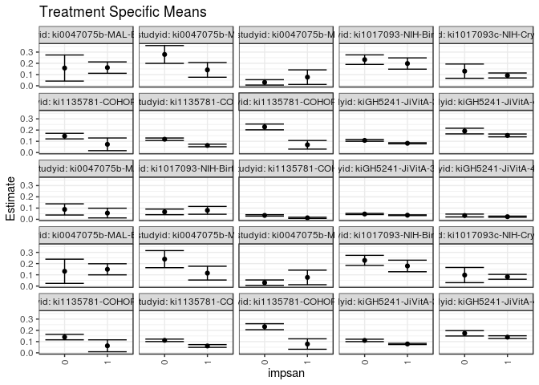

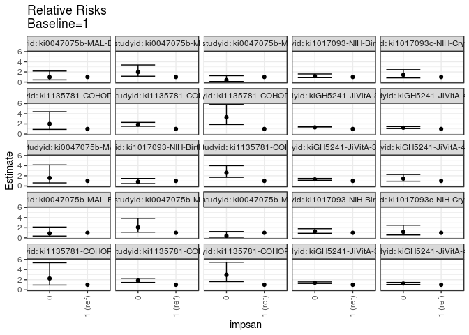

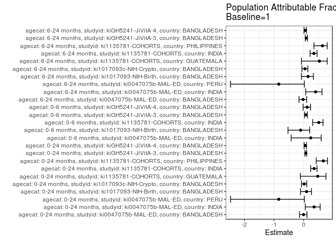

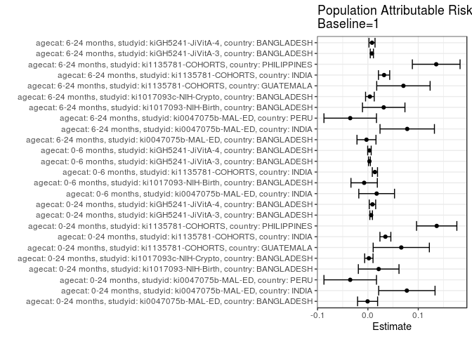

## Results Table

### Parameter: TSM

| agecat | studyid | country | intervention_level | baseline_level | estimate | ci_lower | ci_upper |
| --- | --- | --- | --- | --- | --- | --- | --- |
| 0-24 months | ki0047075b-MAL-ED | BANGLADESH | 1 | NA | 0.1617647 | 0.1111290 | 0.2124004 |
| 0-24 months | ki0047075b-MAL-ED | BANGLADESH | 0 | NA | 0.1578947 | 0.0417171 | 0.2740724 |
| 0-24 months | ki0047075b-MAL-ED | INDIA | 1 | NA | 0.1415366 | 0.0761215 | 0.2069518 |
| 0-24 months | ki0047075b-MAL-ED | INDIA | 0 | NA | 0.2789302 | 0.1996297 | 0.3582306 |
| 0-24 months | ki0047075b-MAL-ED | PERU | 1 | NA | 0.0769231 | 0.0120199 | 0.1418262 |
| 0-24 months | ki0047075b-MAL-ED | PERU | 0 | NA | 0.0303030 | 0.0063807 | 0.0542254 |
| 0-24 months | ki1017093-NIH-Birth | BANGLADESH | 1 | NA | 0.1981520 | 0.1479201 | 0.2483839 |
| 0-24 months | ki1017093-NIH-Birth | BANGLADESH | 0 | NA | 0.2326994 | 0.1904245 | 0.2749744 |
| 0-24 months | ki1017093c-NIH-Crypto | BANGLADESH | 1 | NA | 0.0918292 | 0.0697326 | 0.1139258 |
| 0-24 months | ki1017093c-NIH-Crypto | BANGLADESH | 0 | NA | 0.1301521 | 0.0667739 | 0.1935302 |
| 0-24 months | ki1135781-COHORTS | GUATEMALA | 1 | NA | 0.0731707 | 0.0167735 | 0.1295680 |
| 0-24 months | ki1135781-COHORTS | GUATEMALA | 0 | NA | 0.1462799 | 0.1216700 | 0.1708899 |
| 0-24 months | ki1135781-COHORTS | INDIA | 1 | NA | 0.0633642 | 0.0516668 | 0.0750616 |
| 0-24 months | ki1135781-COHORTS | INDIA | 0 | NA | 0.1184083 | 0.1073759 | 0.1294406 |
| 0-24 months | ki1135781-COHORTS | PHILIPPINES | 1 | NA | 0.0691008 | 0.0307610 | 0.1074405 |
| 0-24 months | ki1135781-COHORTS | PHILIPPINES | 0 | NA | 0.2280355 | 0.2021959 | 0.2538751 |
| 0-24 months | kiGH5241-JiVitA-3 | BANGLADESH | 1 | NA | 0.0823850 | 0.0776988 | 0.0870712 |
| 0-24 months | kiGH5241-JiVitA-3 | BANGLADESH | 0 | NA | 0.1081863 | 0.1002579 | 0.1161146 |
| 0-24 months | kiGH5241-JiVitA-4 | BANGLADESH | 1 | NA | 0.1523906 | 0.1397260 | 0.1650553 |
| 0-24 months | kiGH5241-JiVitA-4 | BANGLADESH | 0 | NA | 0.1912179 | 0.1659590 | 0.2164768 |
| 0-6 months | ki0047075b-MAL-ED | INDIA | 1 | NA | 0.0555556 | 0.0122621 | 0.0988490 |
| 0-6 months | ki0047075b-MAL-ED | INDIA | 0 | NA | 0.0880000 | 0.0382302 | 0.1377698 |
| 0-6 months | ki1017093-NIH-Birth | BANGLADESH | 1 | NA | 0.0797803 | 0.0450149 | 0.1145456 |
| 0-6 months | ki1017093-NIH-Birth | BANGLADESH | 0 | NA | 0.0660575 | 0.0410771 | 0.0910380 |
| 0-6 months | ki1135781-COHORTS | INDIA | 1 | NA | 0.0133735 | 0.0082059 | 0.0185410 |
| 0-6 months | ki1135781-COHORTS | INDIA | 0 | NA | 0.0348545 | 0.0285736 | 0.0411354 |
| 0-6 months | kiGH5241-JiVitA-3 | BANGLADESH | 1 | NA | 0.0365723 | 0.0334254 | 0.0397192 |
| 0-6 months | kiGH5241-JiVitA-3 | BANGLADESH | 0 | NA | 0.0472219 | 0.0422391 | 0.0522048 |
| 0-6 months | kiGH5241-JiVitA-4 | BANGLADESH | 1 | NA | 0.0233090 | 0.0179469 | 0.0286712 |
| 0-6 months | kiGH5241-JiVitA-4 | BANGLADESH | 0 | NA | 0.0338162 | 0.0211962 | 0.0464363 |
| 6-24 months | ki0047075b-MAL-ED | BANGLADESH | 1 | NA | 0.1492537 | 0.0998883 | 0.1986192 |
| 6-24 months | ki0047075b-MAL-ED | BANGLADESH | 0 | NA | 0.1315789 | 0.0238766 | 0.2392813 |
| 6-24 months | ki0047075b-MAL-ED | INDIA | 1 | NA | 0.1150582 | 0.0536744 | 0.1764419 |
| 6-24 months | ki0047075b-MAL-ED | INDIA | 0 | NA | 0.2397298 | 0.1637099 | 0.3157496 |
| 6-24 months | ki0047075b-MAL-ED | PERU | 1 | NA | 0.0769231 | 0.0120199 | 0.1418262 |
| 6-24 months | ki0047075b-MAL-ED | PERU | 0 | NA | 0.0303030 | 0.0063807 | 0.0542254 |
| 6-24 months | ki1017093-NIH-Birth | BANGLADESH | 1 | NA | 0.1789275 | 0.1274192 | 0.2304359 |
| 6-24 months | ki1017093-NIH-Birth | BANGLADESH | 0 | NA | 0.2285478 | 0.1837214 | 0.2733741 |
| 6-24 months | ki1017093c-NIH-Crypto | BANGLADESH | 1 | NA | 0.0822435 | 0.0607243 | 0.1037627 |
| 6-24 months | ki1017093c-NIH-Crypto | BANGLADESH | 0 | NA | 0.0979658 | 0.0304006 | 0.1655311 |
| 6-24 months | ki1135781-COHORTS | GUATEMALA | 1 | NA | 0.0625000 | 0.0094259 | 0.1155741 |
| 6-24 months | ki1135781-COHORTS | GUATEMALA | 0 | NA | 0.1402831 | 0.1158504 | 0.1647158 |
| 6-24 months | ki1135781-COHORTS | INDIA | 1 | NA | 0.0608448 | 0.0487776 | 0.0729120 |
| 6-24 months | ki1135781-COHORTS | INDIA | 0 | NA | 0.1112948 | 0.1002964 | 0.1222932 |
| 6-24 months | ki1135781-COHORTS | PHILIPPINES | 1 | NA | 0.0782118 | 0.0317366 | 0.1246870 |
| 6-24 months | ki1135781-COHORTS | PHILIPPINES | 0 | NA | 0.2324067 | 0.2057559 | 0.2590575 |
| 6-24 months | kiGH5241-JiVitA-3 | BANGLADESH | 1 | NA | 0.0789338 | 0.0736081 | 0.0842596 |
| 6-24 months | kiGH5241-JiVitA-3 | BANGLADESH | 0 | NA | 0.1105241 | 0.0998406 | 0.1212075 |
| 6-24 months | kiGH5241-JiVitA-4 | BANGLADESH | 1 | NA | 0.1395790 | 0.1275149 | 0.1516430 |
| 6-24 months | kiGH5241-JiVitA-4 | BANGLADESH | 0 | NA | 0.1736219 | 0.1499707 | 0.1972731 |

### Parameter: E(Y)

| agecat | studyid | country | intervention_level | baseline_level | estimate | ci_lower | ci_upper |
| --- | --- | --- | --- | --- | --- | --- | --- |
| 0-24 months | ki0047075b-MAL-ED | BANGLADESH | NA | NA | 0.1611570 | 0.1147371 | 0.2075770 |
| 0-24 months | ki0047075b-MAL-ED | INDIA | NA | NA | 0.2188841 | 0.1656771 | 0.2720911 |
| 0-24 months | ki0047075b-MAL-ED | PERU | NA | NA | 0.0418251 | 0.0175848 | 0.0660654 |
| 0-24 months | ki1017093-NIH-Birth | BANGLADESH | NA | NA | 0.2195513 | 0.1870467 | 0.2520558 |
| 0-24 months | ki1017093c-NIH-Crypto | BANGLADESH | NA | NA | 0.0937082 | 0.0727959 | 0.1146204 |
| 0-24 months | ki1135781-COHORTS | GUATEMALA | NA | NA | 0.1394286 | 0.1164638 | 0.1623933 |
| 0-24 months | ki1135781-COHORTS | INDIA | NA | NA | 0.0981013 | 0.0901463 | 0.1060562 |
| 0-24 months | ki1135781-COHORTS | PHILIPPINES | NA | NA | 0.2057095 | 0.1827432 | 0.2286758 |
| 0-24 months | kiGH5241-JiVitA-3 | BANGLADESH | NA | NA | 0.0888302 | 0.0849233 | 0.0927371 |
| 0-24 months | kiGH5241-JiVitA-4 | BANGLADESH | NA | NA | 0.1614449 | 0.1501252 | 0.1727646 |
| 0-6 months | ki0047075b-MAL-ED | INDIA | NA | NA | 0.0729614 | 0.0394957 | 0.1064270 |
| 0-6 months | ki1017093-NIH-Birth | BANGLADESH | NA | NA | 0.0723473 | 0.0519719 | 0.0927227 |
| 0-6 months | ki1135781-COHORTS | INDIA | NA | NA | 0.0272886 | 0.0228458 | 0.0317313 |
| 0-6 months | kiGH5241-JiVitA-3 | BANGLADESH | NA | NA | 0.0396461 | 0.0371429 | 0.0421492 |
| 0-6 months | kiGH5241-JiVitA-4 | BANGLADESH | NA | NA | 0.0263831 | 0.0210411 | 0.0317252 |
| 6-24 months | ki0047075b-MAL-ED | BANGLADESH | NA | NA | 0.1464435 | 0.1015265 | 0.1913605 |
| 6-24 months | ki0047075b-MAL-ED | INDIA | NA | NA | 0.1931330 | 0.1423366 | 0.2439295 |
| 6-24 months | ki0047075b-MAL-ED | PERU | NA | NA | 0.0418251 | 0.0175848 | 0.0660654 |
| 6-24 months | ki1017093-NIH-Birth | BANGLADESH | NA | NA | 0.2103321 | 0.1759902 | 0.2446740 |
| 6-24 months | ki1017093c-NIH-Crypto | BANGLADESH | NA | NA | 0.0862309 | 0.0656987 | 0.1067631 |
| 6-24 months | ki1135781-COHORTS | GUATEMALA | NA | NA | 0.1330222 | 0.1102724 | 0.1557720 |
| 6-24 months | ki1135781-COHORTS | INDIA | NA | NA | 0.0929723 | 0.0849408 | 0.1010038 |
| 6-24 months | ki1135781-COHORTS | PHILIPPINES | NA | NA | 0.2138365 | 0.1897378 | 0.2379351 |
| 6-24 months | kiGH5241-JiVitA-3 | BANGLADESH | NA | NA | 0.0868080 | 0.0821493 | 0.0914667 |
| 6-24 months | kiGH5241-JiVitA-4 | BANGLADESH | NA | NA | 0.1477315 | 0.1371478 | 0.1583151 |

### Parameter: RR

| agecat | studyid | country | intervention_level | baseline_level | estimate | ci_lower | ci_upper |
| --- | --- | --- | --- | --- | --- | --- | --- |
| 0-24 months | ki0047075b-MAL-ED | BANGLADESH | 1 | 1 | 1.0000000 | 1.0000000 | 1.000000 |
| 0-24 months | ki0047075b-MAL-ED | BANGLADESH | 0 | 1 | 0.9760766 | 0.4387519 | 2.171445 |
| 0-24 months | ki0047075b-MAL-ED | INDIA | 1 | 1 | 1.0000000 | 1.0000000 | 1.000000 |
| 0-24 months | ki0047075b-MAL-ED | INDIA | 0 | 1 | 1.9707283 | 1.1498436 | 3.377651 |
| 0-24 months | ki0047075b-MAL-ED | PERU | 1 | 1 | 1.0000000 | 1.0000000 | 1.000000 |
| 0-24 months | ki0047075b-MAL-ED | PERU | 0 | 1 | 0.3939394 | 0.1240553 | 1.250961 |
| 0-24 months | ki1017093-NIH-Birth | BANGLADESH | 1 | 1 | 1.0000000 | 1.0000000 | 1.000000 |
| 0-24 months | ki1017093-NIH-Birth | BANGLADESH | 0 | 1 | 1.1743481 | 0.8619868 | 1.599901 |
| 0-24 months | ki1017093c-NIH-Crypto | BANGLADESH | 1 | 1 | 1.0000000 | 1.0000000 | 1.000000 |
| 0-24 months | ki1017093c-NIH-Crypto | BANGLADESH | 0 | 1 | 1.4173276 | 0.8228329 | 2.441343 |
| 0-24 months | ki1135781-COHORTS | GUATEMALA | 1 | 1 | 1.0000000 | 1.0000000 | 1.000000 |
| 0-24 months | ki1135781-COHORTS | GUATEMALA | 0 | 1 | 1.9991593 | 0.9082974 | 4.400142 |
| 0-24 months | ki1135781-COHORTS | INDIA | 1 | 1 | 1.0000000 | 1.0000000 | 1.000000 |
| 0-24 months | ki1135781-COHORTS | INDIA | 0 | 1 | 1.8686927 | 1.5207085 | 2.296306 |
| 0-24 months | ki1135781-COHORTS | PHILIPPINES | 1 | 1 | 1.0000000 | 1.0000000 | 1.000000 |
| 0-24 months | ki1135781-COHORTS | PHILIPPINES | 0 | 1 | 3.3000432 | 1.8745959 | 5.809404 |
| 0-24 months | kiGH5241-JiVitA-3 | BANGLADESH | 1 | 1 | 1.0000000 | 1.0000000 | 1.000000 |
| 0-24 months | kiGH5241-JiVitA-3 | BANGLADESH | 0 | 1 | 1.3131786 | 1.2048774 | 1.431215 |
| 0-24 months | kiGH5241-JiVitA-4 | BANGLADESH | 1 | 1 | 1.0000000 | 1.0000000 | 1.000000 |
| 0-24 months | kiGH5241-JiVitA-4 | BANGLADESH | 0 | 1 | 1.2547875 | 1.0735783 | 1.466583 |
| 0-6 months | ki0047075b-MAL-ED | INDIA | 1 | 1 | 1.0000000 | 1.0000000 | 1.000000 |
| 0-6 months | ki0047075b-MAL-ED | INDIA | 0 | 1 | 1.5840000 | 0.6047559 | 4.148874 |
| 0-6 months | ki1017093-NIH-Birth | BANGLADESH | 1 | 1 | 1.0000000 | 1.0000000 | 1.000000 |
| 0-6 months | ki1017093-NIH-Birth | BANGLADESH | 0 | 1 | 0.8279934 | 0.4656112 | 1.472415 |
| 0-6 months | ki1135781-COHORTS | INDIA | 1 | 1 | 1.0000000 | 1.0000000 | 1.000000 |
| 0-6 months | ki1135781-COHORTS | INDIA | 0 | 1 | 2.6062400 | 1.7014973 | 3.992065 |
| 0-6 months | kiGH5241-JiVitA-3 | BANGLADESH | 1 | 1 | 1.0000000 | 1.0000000 | 1.000000 |
| 0-6 months | kiGH5241-JiVitA-3 | BANGLADESH | 0 | 1 | 1.2911940 | 1.1248765 | 1.482102 |
| 0-6 months | kiGH5241-JiVitA-4 | BANGLADESH | 1 | 1 | 1.0000000 | 1.0000000 | 1.000000 |
| 0-6 months | kiGH5241-JiVitA-4 | BANGLADESH | 0 | 1 | 1.4507786 | 0.9369836 | 2.246313 |
| 6-24 months | ki0047075b-MAL-ED | BANGLADESH | 1 | 1 | 1.0000000 | 1.0000000 | 1.000000 |
| 6-24 months | ki0047075b-MAL-ED | BANGLADESH | 0 | 1 | 0.8815789 | 0.3646285 | 2.131434 |
| 6-24 months | ki0047075b-MAL-ED | INDIA | 1 | 1 | 1.0000000 | 1.0000000 | 1.000000 |
| 6-24 months | ki0047075b-MAL-ED | INDIA | 0 | 1 | 2.0835524 | 1.1256825 | 3.856496 |
| 6-24 months | ki0047075b-MAL-ED | PERU | 1 | 1 | 1.0000000 | 1.0000000 | 1.000000 |
| 6-24 months | ki0047075b-MAL-ED | PERU | 0 | 1 | 0.3939394 | 0.1240553 | 1.250961 |
| 6-24 months | ki1017093-NIH-Birth | BANGLADESH | 1 | 1 | 1.0000000 | 1.0000000 | 1.000000 |
| 6-24 months | ki1017093-NIH-Birth | BANGLADESH | 0 | 1 | 1.2773203 | 0.9055634 | 1.801693 |
| 6-24 months | ki1017093c-NIH-Crypto | BANGLADESH | 1 | 1 | 1.0000000 | 1.0000000 | 1.000000 |
| 6-24 months | ki1017093c-NIH-Crypto | BANGLADESH | 0 | 1 | 1.1911683 | 0.5695964 | 2.491030 |
| 6-24 months | ki1135781-COHORTS | GUATEMALA | 1 | 1 | 1.0000000 | 1.0000000 | 1.000000 |
| 6-24 months | ki1135781-COHORTS | GUATEMALA | 0 | 1 | 2.2445302 | 0.9433052 | 5.340706 |
| 6-24 months | ki1135781-COHORTS | INDIA | 1 | 1 | 1.0000000 | 1.0000000 | 1.000000 |
| 6-24 months | ki1135781-COHORTS | INDIA | 0 | 1 | 1.8291591 | 1.4670043 | 2.280718 |
| 6-24 months | ki1135781-COHORTS | PHILIPPINES | 1 | 1 | 1.0000000 | 1.0000000 | 1.000000 |
| 6-24 months | ki1135781-COHORTS | PHILIPPINES | 0 | 1 | 2.9715042 | 1.6231713 | 5.439868 |
| 6-24 months | kiGH5241-JiVitA-3 | BANGLADESH | 1 | 1 | 1.0000000 | 1.0000000 | 1.000000 |
| 6-24 months | kiGH5241-JiVitA-3 | BANGLADESH | 0 | 1 | 1.4002118 | 1.2500110 | 1.568461 |
| 6-24 months | kiGH5241-JiVitA-4 | BANGLADESH | 1 | 1 | 1.0000000 | 1.0000000 | 1.000000 |
| 6-24 months | kiGH5241-JiVitA-4 | BANGLADESH | 0 | 1 | 1.2438974 | 1.0575165 | 1.463127 |

### Parameter: PAR

| agecat | studyid | country | intervention_level | baseline_level | estimate | ci_lower | ci_upper |
| --- | --- | --- | --- | --- | --- | --- | --- |
| 0-24 months | ki0047075b-MAL-ED | BANGLADESH | 1 | NA | -0.0006077 | -0.0205087 | 0.0192933 |
| 0-24 months | ki0047075b-MAL-ED | INDIA | 1 | NA | 0.0773475 | 0.0213938 | 0.1333012 |
| 0-24 months | ki0047075b-MAL-ED | PERU | 1 | NA | -0.0350980 | -0.0872308 | 0.0170348 |
| 0-24 months | ki1017093-NIH-Birth | BANGLADESH | 1 | NA | 0.0213993 | -0.0189539 | 0.0617524 |
| 0-24 months | ki1017093c-NIH-Crypto | BANGLADESH | 1 | NA | 0.0018790 | -0.0064230 | 0.0101809 |
| 0-24 months | ki1135781-COHORTS | GUATEMALA | 1 | NA | 0.0662578 | 0.0104736 | 0.1220421 |
| 0-24 months | ki1135781-COHORTS | INDIA | 1 | NA | 0.0347370 | 0.0239241 | 0.0455500 |
| 0-24 months | ki1135781-COHORTS | PHILIPPINES | 1 | NA | 0.1366087 | 0.0966069 | 0.1766105 |
| 0-24 months | kiGH5241-JiVitA-3 | BANGLADESH | 1 | NA | 0.0064452 | 0.0038496 | 0.0090407 |
| 0-24 months | kiGH5241-JiVitA-4 | BANGLADESH | 1 | NA | 0.0090543 | 0.0026914 | 0.0154171 |
| 0-6 months | ki0047075b-MAL-ED | INDIA | 1 | NA | 0.0174058 | -0.0180442 | 0.0528558 |
| 0-6 months | ki1017093-NIH-Birth | BANGLADESH | 1 | NA | -0.0074330 | -0.0335971 | 0.0187311 |
| 0-6 months | ki1135781-COHORTS | INDIA | 1 | NA | 0.0139151 | 0.0087487 | 0.0190815 |
| 0-6 months | kiGH5241-JiVitA-3 | BANGLADESH | 1 | NA | 0.0030738 | 0.0012166 | 0.0049310 |
| 0-6 months | kiGH5241-JiVitA-4 | BANGLADESH | 1 | NA | 0.0030741 | -0.0003971 | 0.0065453 |
| 6-24 months | ki0047075b-MAL-ED | BANGLADESH | 1 | NA | -0.0028102 | -0.0216654 | 0.0160450 |
| 6-24 months | ki0047075b-MAL-ED | INDIA | 1 | NA | 0.0780749 | 0.0240657 | 0.1320841 |
| 6-24 months | ki0047075b-MAL-ED | PERU | 1 | NA | -0.0350980 | -0.0872308 | 0.0170348 |
| 6-24 months | ki1017093-NIH-Birth | BANGLADESH | 1 | NA | 0.0314046 | -0.0107626 | 0.0735718 |
| 6-24 months | ki1017093c-NIH-Crypto | BANGLADESH | 1 | NA | 0.0039874 | -0.0046169 | 0.0125916 |
| 6-24 months | ki1135781-COHORTS | GUATEMALA | 1 | NA | 0.0705222 | 0.0175268 | 0.1235175 |
| 6-24 months | ki1135781-COHORTS | INDIA | 1 | NA | 0.0321275 | 0.0209685 | 0.0432866 |
| 6-24 months | ki1135781-COHORTS | PHILIPPINES | 1 | NA | 0.1356247 | 0.0882718 | 0.1829776 |
| 6-24 months | kiGH5241-JiVitA-3 | BANGLADESH | 1 | NA | 0.0078741 | 0.0047441 | 0.0110042 |
| 6-24 months | kiGH5241-JiVitA-4 | BANGLADESH | 1 | NA | 0.0081525 | 0.0021467 | 0.0141583 |

### Parameter: PAF

| agecat | studyid | country | intervention_level | baseline_level | estimate | ci_lower | ci_upper |
| --- | --- | --- | --- | --- | --- | --- | --- |
| 0-24 months | ki0047075b-MAL-ED | BANGLADESH | 1 | NA | -0.0037707 | -0.1351730 | 0.1124210 |
| 0-24 months | ki0047075b-MAL-ED | INDIA | 1 | NA | 0.3533720 | 0.0546314 | 0.5577093 |
| 0-24 months | ki0047075b-MAL-ED | PERU | 1 | NA | -0.8391608 | -2.4633938 | 0.0233532 |
| 0-24 months | ki1017093-NIH-Birth | BANGLADESH | 1 | NA | 0.0974681 | -0.1059867 | 0.2634959 |
| 0-24 months | ki1017093c-NIH-Crypto | BANGLADESH | 1 | NA | 0.0200513 | -0.0725405 | 0.1046497 |
| 0-24 months | ki1135781-COHORTS | GUATEMALA | 1 | NA | 0.4752099 | -0.1111802 | 0.7521513 |
| 0-24 months | ki1135781-COHORTS | INDIA | 1 | NA | 0.3540936 | 0.2381146 | 0.4524176 |
| 0-24 months | ki1135781-COHORTS | PHILIPPINES | 1 | NA | 0.6640857 | 0.4231609 | 0.8043849 |
| 0-24 months | kiGH5241-JiVitA-3 | BANGLADESH | 1 | NA | 0.0725562 | 0.0426991 | 0.1014822 |
| 0-24 months | kiGH5241-JiVitA-4 | BANGLADESH | 1 | NA | 0.0560826 | 0.0158659 | 0.0946558 |
| 0-6 months | ki0047075b-MAL-ED | INDIA | 1 | NA | 0.2385621 | -0.4206987 | 0.5918996 |
| 0-6 months | ki1017093-NIH-Birth | BANGLADESH | 1 | NA | -0.1027409 | -0.5282394 | 0.2042887 |
| 0-6 months | ki1135781-COHORTS | INDIA | 1 | NA | 0.5099242 | 0.3053499 | 0.6542514 |
| 0-6 months | kiGH5241-JiVitA-3 | BANGLADESH | 1 | NA | 0.0775310 | 0.0291038 | 0.1235427 |
| 0-6 months | kiGH5241-JiVitA-4 | BANGLADESH | 1 | NA | 0.1165181 | -0.0189555 | 0.2339800 |
| 6-24 months | ki0047075b-MAL-ED | BANGLADESH | 1 | NA | -0.0191898 | -0.1563308 | 0.1016863 |
| 6-24 months | ki0047075b-MAL-ED | INDIA | 1 | NA | 0.4042543 | 0.0689214 | 0.6188152 |
| 6-24 months | ki0047075b-MAL-ED | PERU | 1 | NA | -0.8391608 | -2.4633938 | 0.0233532 |
| 6-24 months | ki1017093-NIH-Birth | BANGLADESH | 1 | NA | 0.1493095 | -0.0753942 | 0.3270613 |
| 6-24 months | ki1017093c-NIH-Crypto | BANGLADESH | 1 | NA | 0.0462408 | -0.0584953 | 0.1406134 |
| 6-24 months | ki1135781-COHORTS | GUATEMALA | 1 | NA | 0.5301535 | -0.0763444 | 0.7949023 |
| 6-24 months | ki1135781-COHORTS | INDIA | 1 | NA | 0.3455601 | 0.2181007 | 0.4522420 |
| 6-24 months | ki1135781-COHORTS | PHILIPPINES | 1 | NA | 0.6342448 | 0.3469720 | 0.7951438 |
| 6-24 months | kiGH5241-JiVitA-3 | BANGLADESH | 1 | NA | 0.0907076 | 0.0541295 | 0.1258711 |
| 6-24 months | kiGH5241-JiVitA-4 | BANGLADESH | 1 | NA | 0.0551847 | 0.0135257 | 0.0950844 |